# BUDT758X

- Assignment #6
- Instructor: Prof. Sean Barnes
- Studnet: Xukun(Frank) LIU (https://www.xukun-liu.com)
- Topics: # Data Viz # Matplotlib # Seaborn # Data Visualization
- Apr 12, 2019

Basic Info

- Question - a.
- Question - b.
- Question - c.
- Question - d.
- Question - e.
- Question - f.

**Info**

- Airbnb has become an extremely popular platform for connecting travelers with housing rentals across the world.
- Its users can search its extensive database of rentals, in the hopes of finding a suitable match for their travels.
- Let's explore a data set of Airbnb rentals in Asheville, North Carolina
- Preview the document, the destination of Prof. Barnes's recent Spring Break getaway.
- The data was collected on February 17, 2019 (courtesy of Inside Airbnb) and contains the following relevant information about the rentals:
  - Unique identifiers for the rental (id) and the host (host_id)
  - Name for the rental (name) and host (host_name)
  - Location information (neighborhood - ZIP code, latitude/longitude)
  - Room type
  - Average nightly price (in dollars)
  - Minimum nights per stay
  - Number of reviews for the rental
  - Date of most recent review
  - Number of reviews per month
  - Number of listings by the host in the last month
  - Number of available days for rental over the next year (availability_365)
- Complete the following exercises using the provided data:

```python
import pandas as pd
import matplotlib.pyplot as plt
import seaborn as sns
%pylab inline
```

**a. (1 point)**

- Perform an analysis of missingness in the data (i.e., what is the extent of missing values in the data and where do they occur?).
- Based on what you observe, perform an appropriate set of processing operations (if applicable) to manage the data appropriately.
- Please make sure to justify any processing steps (or lack of steps) that you perform.

```python
dt = pd.read_csv('airbnb_asheville_listings.csv')
dt.head()
```

|  | id | name | host_id | host_name | neighbourhood_group | neighbourhood | latitude | longitude | room_type | price | minimum_nights | number_of_reviews | last_review | reviews_per_month | calculated_host_listings_count | availability_365 |
| --- | --- | --- | --- | --- | --- | --- | --- | --- | --- | --- | --- | --- | --- | --- | --- | --- |
| 0 | 38585 | Charming Victorian twin BR for 2 | 165529 | Evelyne | NaN | 28804 | 35.65146 | -82.62792 | Private room | 45 | 1 | 121 | 2018-11-25 | 1.20 | 1 | 60 |
| 1 | 80905 | French Industrial Chic Loft | 427027 | AshevilleStay | NaN | 28801 | 35.59701 | -82.55237 | Entire home/apt | 765 | 1 | 92 | 2018-12-02 | 1.01 | 12 | 361 |
| 2 | 108061 | Walk downtown or UNCA, Pets OK! | 320564 | Lisa | NaN | 28801 | 35.60670 | -82.55563 | Entire home/apt | 75 | 2 | 85 | 2018-12-25 | 0.94 | 2 | 9 |
| 3 | 155305 | Cottage! BonPaul + Sharky's Hostel | 746673 | BonPaul | NaN | 28806 | 35.57972 | -82.59617 | Entire home/apt | 107 | 1 | 195 | 2019-02-10 | 2.12 | 7 | 339 |
| 4 | 156805 | Private Room "Ader" at BPS Hostel | 746673 | BonPaul | NaN | 28806 | 35.57755 | -82.59697 | Private room | 71 | 1 | 51 | 2019-01-11 | 0.56 | 7 | 349 |

```python
dt.shape
```

```
(2053, 16)
```

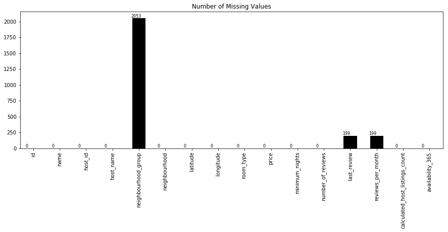

```python
ax = dt.isnull().sum().plot(kind='bar',figsize=(15,5),rot=90,color='k',grid=False)
ax.set_title('Number of Missing Values',fontsize=12)

for i in ax.patches:
    # get_x pulls left or right; get_height pushes up or down
    ax.text(i.get_x()-0.05, i.get_height()+12, \
            str(i.get_height()), fontsize=8, color='k',
                rotation=0)
```

**Note:**

- the data set has 2053 rows and 16 cols
- in the data set, col - neighbourhood_group has 2053 missing values
- which means col - neighbourhood_group is all empty
- We should drop col - neighbourhood_group

```python
dt=dt.drop(columns='neighbourhood_group')
```

```python
dt[dt['last_review'].isnull()].head(5)
```

|  | id | name | host_id | host_name | neighbourhood | latitude | longitude | room_type | price | minimum_nights | number_of_reviews | last_review | reviews_per_month | calculated_host_listings_count | availability_365 |
| --- | --- | --- | --- | --- | --- | --- | --- | --- | --- | --- | --- | --- | --- | --- | --- |
| 55 | 1138179 | West Asheville | 6243494 | Mark | 28806 | 35.58627 | -82.60428 | Private room | 60 | 39 | 0 | NaN | NaN | 1 | 365 |
| 200 | 4510499 | Lovely 3 bdrm 2 bath Kenilworth | 14079532 | Jenny | 28803 | 35.57564 | -82.54149 | Entire home/apt | 150 | 1 | 0 | NaN | NaN | 1 | 0 |
| 277 | 6544722 | Sunny Spacious 2 Bedroom 1 Mi town | 20446462 | Cassie | 28803 | 35.57742 | -82.54288 | Entire home/apt | 110 | 13 | 0 | NaN | NaN | 1 | 0 |
| 280 | 6609327 | The Barn At Mountain Meadows | 26946813 | Anna | 28804 | 35.63373 | -82.49752 | Entire home/apt | 295 | 2 | 0 | NaN | NaN | 1 | 295 |
| 301 | 7063293 | Mountaintop Log Cabin w/Pano View | 14480896 | Birgit | 28704 | 35.48087 | -82.50600 | Entire home/apt | 285 | 3 | 0 | NaN | NaN | 1 | 211 |

```python
sum(dt['reviews_per_month'].isnull( ) != dt['last_review'].isnull())
```

```
0
```

```python
sum(dt.loc[dt['reviews_per_month'].isnull( ),'number_of_reviews'] != 0)
```

```
0
```

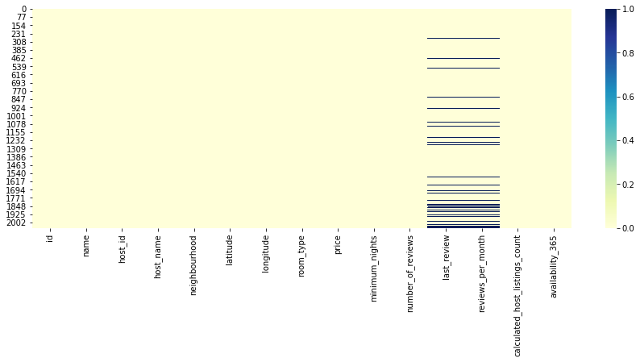

```python
plt.figure(figsize=(15,5))
sns.heatmap(dt.isnull(),cmap="YlGnBu")
```

**Note:**

- We could tell that last_review and reviews_per_month share exactly same rows
- but we should not delet these rows
- if we look at another col - number_of_reviews, we could notice that all of them are 0 (zero)
- So the missing values in cols: last_review and reviews_per_month are correct
- we should not delet them of change them anyway

**b. (1 point)**

- Analyze and describe the distribution of average nightly price in the data set.

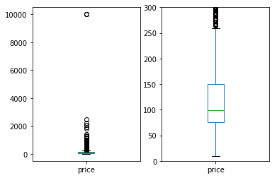

```python
plt.subplot(1,2,1)
dt['price'].plot(kind='box')
plt.subplot(1,2,2)
dt['price'].plot(kind='box',ylim = (0,300))
```

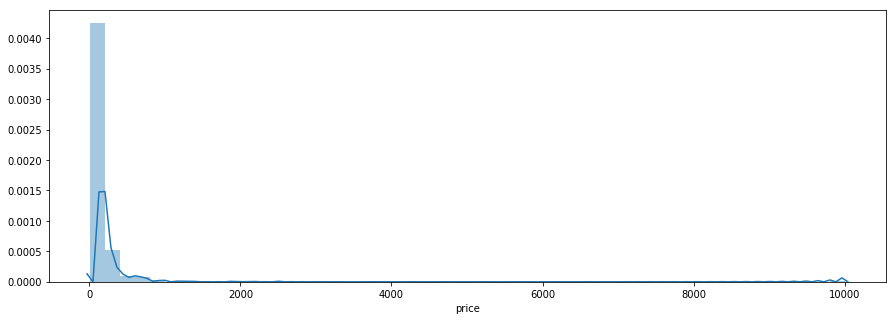

```python
plt.figure(figsize=(15,5))
sns.distplot(dt['price'],hist=True)
```

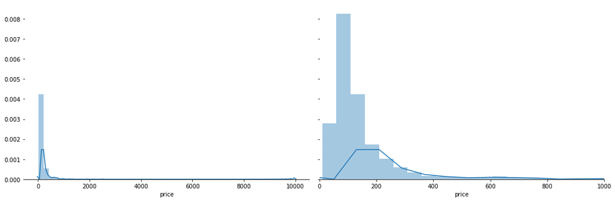

```python
fig,axs = plt.subplots(1, 2, sharey=True, figsize=(15,5))
sns.despine(left=True)
sns.distplot(dt['price'],hist=True,ax=axs[0])
sns.distplot(dt['price'],hist=True,ax=axs[1],bins=200)
axs[1].set(xlim=[0,1000])
fig.tight_layout()
```

**Note:**

- From the above plot, we could tell the prices have very large/wide distribution
- Some Airbnbs even have house price as high as around 10000 per night, but that is only a few of them
- If we exclude these outliers, we could have a better viz result
- And we could conclude that most of the price are between 0 and 400 per night

**c. (1 point)**

- The room type is one of the most important characteristics of the rental, and has a significant impact on the average nightly price.
- Analyze the relationship between the room type and average nightly price, and describe your results.

```python
dt.room_type.unique()
```

```
array(['Private room', 'Entire home/apt', 'Shared room'], dtype=object)
```

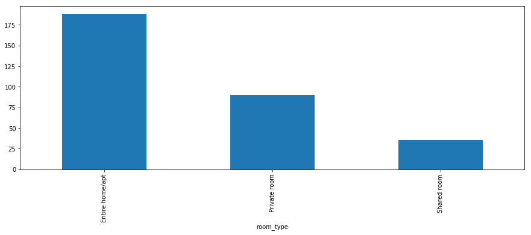

```python
plt.figure(figsize=(15,5))
dt.groupby('room_type').mean().price.plot(kind='bar')
```

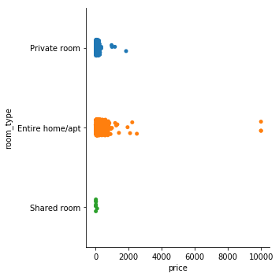

```python
plt.figure(figsize=(15,5))
sns.catplot(y='room_type',x='price',data = dt,orient='h',kind='strip')
```

**Note:**

- From the above plots, we could tell the 'Entire home/apt' has the highest avg price
- If we take a closer look, we could find that, 'Entire home/apt' is also the most common airbnb type among all the listing
- We could also conclude that 'Entire home/apt' has wider price range: there are servel listings have avg price over 2000 dollor per night

**d. (2 points)**

- Aside from the size of the rental, the location is probably the other critical determinant of price.
- Analyze the distribution of rentals by location and the relationship between the location of the rental and average nightly price, and describe your results.

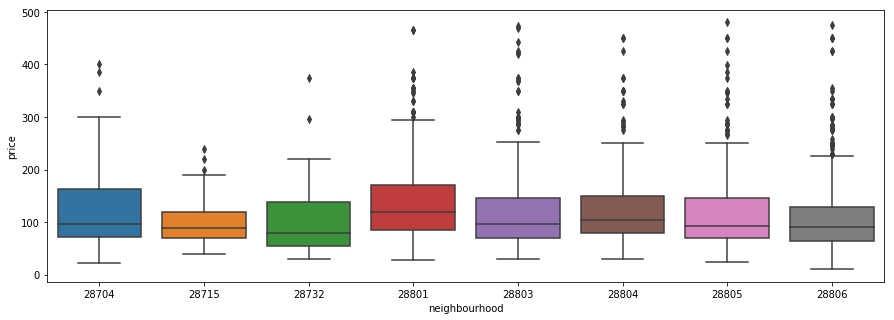

```python
plt.figure(figsize=(15,5))
sns.boxplot(y='price',x='neighbourhood',data=dt[dt['price']<500])
```

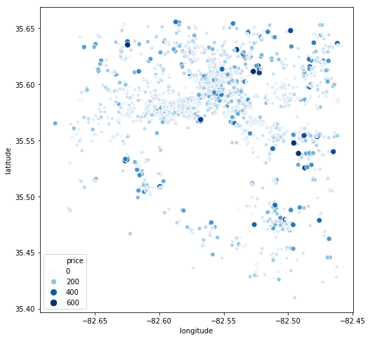

```python
fig = plt.figure(figsize=(8,8))
sns.scatterplot(y='latitude',x='longitude', size = 'price', hue='price', data = dt[dt['price']<500],palette='Blues')
```

**Note:**

- From the above plots, we could tell in neighbourhood 28801 has relative higher avg nightly price.
- In the map we could also tell, the listings with high price are relatively close to each other
- It might because the are in the downtown or that area has better environment

**e. (2 points)**

- Analyze and describe the distribution of the minimum number of nights for each stay.
- Then, segment your analysis according to room type.
- Does this segmentation provide any additional clarity on the requirements specified by hosts on the minimum number of nights for each stay?
- Please base your explanation on your results.

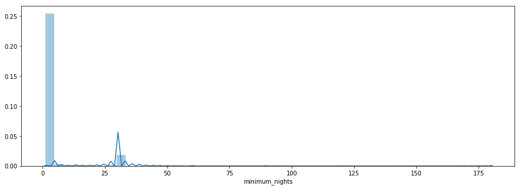

```python
plt.figure(figsize=(15,5))
sns.distplot(dt.minimum_nights,hist=True,bins=50)
```

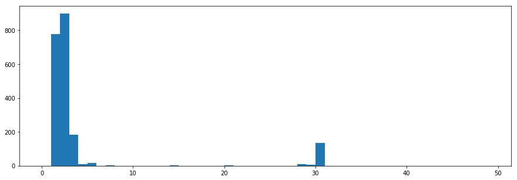

```python
plt.figure(figsize=(15,5))
my_bin = list(range(50))
ax_min_days = plt.hist(dt.minimum_nights,range=(0,50),bins=my_bin)
```

```python
for i in range(len(ax_min_days[0])):
    print('{} host(s) required {}-night minimum stay'.format(int(ax_min_days[0][i]),ax_min_days[1][i+1]))
```

```
0 host(s) required 1-night minimum stay
777 host(s) required 2-night minimum stay
899 host(s) required 3-night minimum stay
184 host(s) required 4-night minimum stay
9 host(s) required 5-night minimum stay
17 host(s) required 6-night minimum stay
0 host(s) required 7-night minimum stay
4 host(s) required 8-night minimum stay
0 host(s) required 9-night minimum stay
0 host(s) required 10-night minimum stay
0 host(s) required 11-night minimum stay
0 host(s) required 12-night minimum stay
0 host(s) required 13-night minimum stay
1 host(s) required 14-night minimum stay
3 host(s) required 15-night minimum stay
```

[output cut: 34 more lines]

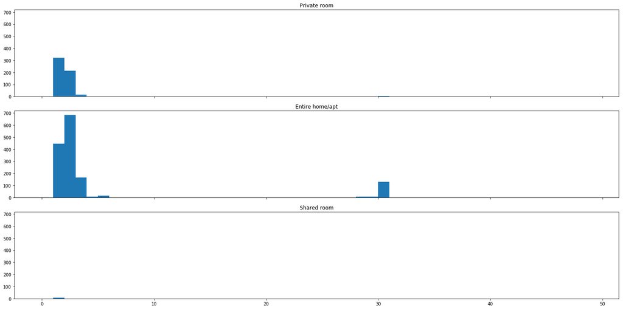

```python
fig,axs = plt.subplots(3, 1, sharex=True,sharey=True, figsize=(20,10))
axs[0].hist(dt[dt.room_type == 'Private room'].minimum_nights,range=(0,50),bins=my_bin)
axs[0].set_title('Private room')
axs[1].hist(dt[dt.room_type == 'Entire home/apt'].minimum_nights,range=(0,50),bins=my_bin)
axs[1].set_title('Entire home/apt')
axs[2].hist(dt[dt.room_type == 'Shared room'].minimum_nights,range=(0,50),bins=my_bin)
axs[2].set_title('Shared room')
fig.tight_layout()
```

**Note:**

**f. (3 points)**

- Perform an analysis of listing strategies, focusing on the hosts with at least 5 listings in the data set.
- Specifically, select 3 such hosts and analyze the listings for each of these hosts (separately).
- Describe in detail what you believe their strategy to be in terms of the types of properties that they acquire and make available for Airbnb travelers.

```python
dt.host_id.value_counts(sort=True,ascending=False).head(5)
```

```
96187307     22
149601167    22
167186184    17
134903005    16
151397468    13
Name: host_id, dtype: int64
```

```python
Steve = dt[dt.host_id==96187307]
```

```python
TurnKey = dt[dt.host_id==149601167]
```

```python
Towns = dt[dt.host_id==167186184]
```

```python
Steve.head(5)
```

|  | id | name | host_id | host_name | neighbourhood | latitude | longitude | room_type | price | minimum_nights | number_of_reviews | last_review | reviews_per_month | calculated_host_listings_count | availability_365 |
| --- | --- | --- | --- | --- | --- | --- | --- | --- | --- | --- | --- | --- | --- | --- | --- |
| 799 | 16937948 | Avery's Creek | 96187307 | Steve | 28704 | 35.44121 | -82.57294 | Entire home/apt | 900 | 1 | 20 | 2018-12-16 | 0.95 | 22 | 226 |
| 800 | 16937957 | Cove Cottage | 96187307 | Steve | 28805 | 35.61030 | -82.52244 | Entire home/apt | 450 | 1 | 18 | 2018-12-30 | 0.82 | 22 | 363 |
| 801 | 16937982 | The Reed Cottage at Biltmore Village; Perfect ... | 96187307 | Steve | 28803 | 35.56311 | -82.53946 | Entire home/apt | 275 | 1 | 4 | 2018-07-16 | 0.18 | 22 | 47 |
| 802 | 16937995 | Upstream Cottage | 96187307 | Steve | 28806 | 35.56783 | -82.56626 | Entire home/apt | 500 | 1 | 30 | 2019-01-06 | 1.30 | 22 | 318 |
| 803 | 16937997 | Asheville Cabin | 96187307 | Steve | 28804 | 35.62512 | -82.52979 | Entire home/apt | 450 | 1 | 43 | 2019-02-03 | 1.93 | 22 | 268 |

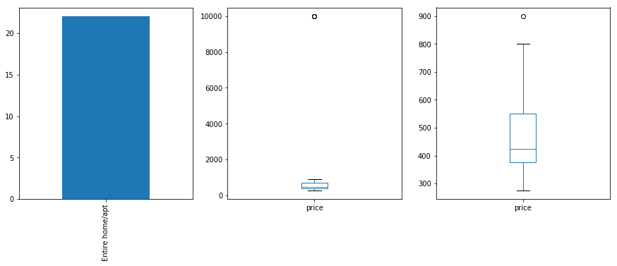

```python
plt.figure(figsize=(15,5))

plt.subplot(1,3,1)
Steve.room_type.value_counts().plot(kind='bar')

plt.subplot(1,3,2)
Steve.price.plot(kind='box')

plt.subplot(1,3,3)
Steve[Steve.price<2000].price.plot(kind='box')
```

```python
TurnKey.head(5)
```

|  | id | name | host_id | host_name | neighbourhood | latitude | longitude | room_type | price | minimum_nights | number_of_reviews | last_review | reviews_per_month | calculated_host_listings_count | availability_365 |
| --- | --- | --- | --- | --- | --- | --- | --- | --- | --- | --- | --- | --- | --- | --- | --- |
| 1378 | 23441905 | Cute 1BR w/ Updates - Steps to Downtown | 149601167 | TurnKey Vacation Rentals | 28801 | 35.59953 | -82.55403 | Entire home/apt | 59 | 30 | 1 | 2019-01-01 | 0.63 | 22 | 335 |
| 1446 | 23910106 | 1 BR Downtown Asheville - Steps Away From the ... | 149601167 | TurnKey Vacation Rentals | 28801 | 35.59959 | -82.55388 | Entire home/apt | 107 | 2 | 3 | 2018-08-19 | 0.28 | 22 | 340 |
| 1492 | 24512884 | Walk Everywhere Downtown! 1BR Corner Condo | 149601167 | TurnKey Vacation Rentals | 28801 | 35.59893 | -82.55538 | Entire home/apt | 108 | 2 | 5 | 2019-01-21 | 0.55 | 22 | 354 |
| 1543 | 25309332 | Modern 2BR Near Downtown | 149601167 | TurnKey Vacation Rentals | 28804 | 35.63555 | -82.59263 | Entire home/apt | 86 | 2 | 6 | 2018-08-26 | 0.71 | 22 | 320 |
| 1546 | 25337854 | Town & Country 3BR w/ Huge Lawn | 149601167 | TurnKey Vacation Rentals | 28805 | 35.61372 | -82.48171 | Entire home/apt | 139 | 2 | 2 | 2018-09-30 | 0.39 | 22 | 335 |

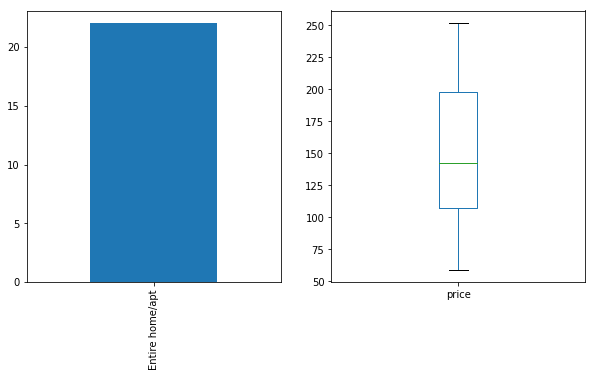

```python
plt.figure(figsize=(10,5))

plt.subplot(1,2,1)
TurnKey.room_type.value_counts().plot(kind='bar')

plt.subplot(1,2,2)
TurnKey.price.plot(kind='box')
```

```python
Towns.head(5)
```

|  | id | name | host_id | host_name | neighbourhood | latitude | longitude | room_type | price | minimum_nights | number_of_reviews | last_review | reviews_per_month | calculated_host_listings_count | availability_365 |
| --- | --- | --- | --- | --- | --- | --- | --- | --- | --- | --- | --- | --- | --- | --- | --- |
| 1960 | 31260007 | New, Contemporary South Slope Townhome with Pr... | 167186184 | Towns | 28801 | 35.58764 | -82.55228 | Entire home/apt | 595 | 1 | 0 | NaN | NaN | 17 | 304 |
| 1961 | 31267687 | New luxury in the heart of downtown | 167186184 | Towns | 28801 | 35.59182 | -82.55587 | Entire home/apt | 550 | 1 | 1 | 2019-01-23 | 1.0 | 17 | 324 |
| 1962 | 31315518 | New, Luxury Condo in Downtown Asheville Condot... | 167186184 | Towns | 28801 | 35.59356 | -82.55689 | Entire home/apt | 750 | 1 | 0 | NaN | NaN | 17 | 261 |
| 1963 | 31318558 | New, Luxury Condo in Downtown Asheville Condot... | 167186184 | Towns | 28801 | 35.59190 | -82.55717 | Entire home/apt | 550 | 1 | 0 | NaN | NaN | 17 | 247 |
| 1964 | 31318559 | New, Luxury Condo in Downtown Asheville Condot... | 167186184 | Towns | 28801 | 35.59233 | -82.55619 | Entire home/apt | 650 | 1 | 1 | 2019-01-20 | 1.0 | 17 | 332 |

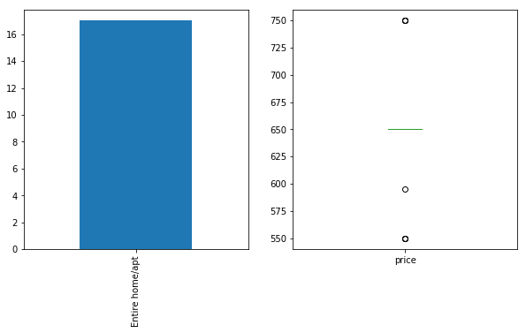

```python
plt.figure(figsize=(10,5))

plt.subplot(1,2,1)
Towns.room_type.value_counts().plot(kind='bar')

plt.subplot(1,2,2)
Towns.price.plot(kind='box')
```

```python
Towns.price.value_counts()
```

```
650    10
750     3
550     3
595     1
Name: price, dtype: int64
```

**Notes:**